# Module 10 Lecture - Mixed Effects Designs

Analysis of Variance

Quinton Quagliano, M.S., C.S.P

Department of Educational Psychology

# 1 Overview and Introduction

Agenda

1 Overview and Introduction

2 The Mixed Effects Model

3 Conclusion

## 1.1 Learning Objectives

- Understand the integration of between-subjects and within-subjects variables in an ANOVA context, and how to describe their different sources of variances
- Understand the assumptions we must consider and how interactions occur in this type of model
- Understand the common scenarios in which this type of model may be used

## 1.2 Introduction

- In some cases, we are likely to have both **between-subjects variables** and **within-subjects variables** variables that we are interested in simultaneously
  - This most often occurs with some element of measuring two or more groups of people across several time points, where time is within subjects and some type of “treatment” is between
- **Important: While time may be the most commonly used within-subjects variable, it isn't the only one we can use!**
- Examples:
  - Measuring impact of active learning in one classroom vs. passive learning in another classroom (between), over 3 time points in a semester (within), on current percentage grade
  - Measuring impact of a novel medication vs. an established one, on two separate groups (between), across 5 days (within), on blood pressure
  - Measuring burn-out among nurses vs medical assistants (between), when all of them are on an old staffing model at the start of the month, and a new staffing model at the end (within)
- **Discuss: Based on the examples above, try to come up with two more of your own that use both between and within subjects variables. Try to come up with one using time as within subjects (like the first two examples) and one not using time explicitly (like the last example)**

# 2 The Mixed Effects Model

Agenda

1 Overview and Introduction

2 The Mixed Effects Model

3 Conclusion

## 2.1 Introduction

- A **mixed effects model** is a type of factorial ANOVA that uses both between-subjects and within-subjects variables as independent variables
  - Remember, a factorial ANOVA will be different from a one-way ANOVA in that it has more than one independent variable
- **Important: This being a factorial ANOVA means it belongs in the same class as something like our initial two-way ANOVAs! It's just a bit more complicated because of having the two different types of variables**
- **Discuss: Speaking of the two-way ANOVA, describe a scenario or research question which would necessitate use of that model**

## 2.2 Example comparisons to Other Types of ANOVA

- **Important: Remember that choosing the right test for the right scenario is one of the most important, foundational statistical skills!**

### Comparison to One-way ANOVA

- The one-way ANOVA only allows for the testing of one between-subjects factor, with at least 3 levels, whereas the mixed effects ANOVA allows for testing both a between-subjects and within-subjects factor on a single continuous outcome
- Illustrative examples:
  - One-way: How does these online, in-person, and hybrid sections compare on total points earned in class
  - Mixed: How does these online, in-person, and hybrid sections compare on total points earned in class, when compared across 3 time points in the semester

### Comparison to Two-way ANOVA

- The two-way ANOVA usually consists of two between-subjects factors on a single continuous outcome, but the mixed effects ANOVA has at least one within-subjects and at least one between-subjects
- Illustrative examples:
  - Two-way: How do different sexes and different levels of student (undergrad or graduate) differ on their reported feelings of safely on campus
  - Mixed: How do different sexes of student differ on their reported feelings of safely on campus at each semester in an 8-semester program

### Comparison to Repeated Measures

- The repeated-measures ANOVA usually consists of one within-subjects factor, with at least 3 levels, on a single continuous outcome, but the mixed effects ANOVA has at least one within-subjects and at least one between-subjects
- Illustrative examples:
  - Two-way: How do students differ in their stress level at 5 different points in the semester
  - Mixed: How do different sexes of student differ on their reported feelings of safely on campus at each semester in an 8-semester program
- **Discuss: Review: name or describe a non-parametric options for one-way ANOVA, Two-way ANOVA, and Repeated Measures ANOVA.**

## 2.3 Sources of Variance

- 5 sources:
  - Between Subjects
    - Groups
    - Within groups
  - Within Subjects
    - Intervals
    - Interval * Groups Interaction
    - Error

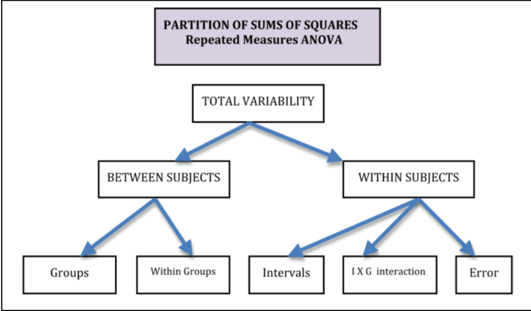

- Example:
  - I am measuring max running speed in sprinting athletes who are on a keto diet vs those who are not, on 5 consecutive weeks
  - Sources of variability:
    - Differences between keto and control diet groups
    - Differences within keto and control diet groups
    - Differences between participant speeds at different weeks
    - Interaction between intervals of weeks and treatment group
    - Error
- **Discuss: Look back on the sources of variance among one or two way ANOVAs, how does this differ from those models?**

## 2.4 Assumptions

- Homogeneity of variances - Levene’s test
- Sphericity - Mauchly test / Greenhouse-Geisser
- Normality
- Independence
- Scale of Measurement

## 2.5 Extensions

- **Important: You can do a mixed effects model with more than two variables, but keep in mind limitations on interpretability!**
- Remember to remain theory-driven in your approach to analysis and be prepared to explain your decision-making
- It’s reasonable to consider other options, like a multiple regression model, if the mixed effects model becomes too “bloated”

# 3 Conclusion

Agenda

1 Overview and Introduction

2 The Mixed Effects Model

3 Conclusion

## 3.1 Recap

- In many ways, the mixed effects tests is, naturally, a mix of a one-way ANOVA and repeated-measures ANOVA! It shares many of their assumptions and considerations, but now put together in a single model
- Many scenarios involving measure two or more groups of people over a certain amount of time, may necessitate use of the mixed effects model
- Don’t be afraid to consider other options or models if interpretation becomes too complex!

## 3.2 Lecture Check-in

- Make sure to complete any lecture check-in tasks associated with this lecture!

[figure not shown]

Module 10 Lecture - Mixed Effects Designs || Analysis of Variance